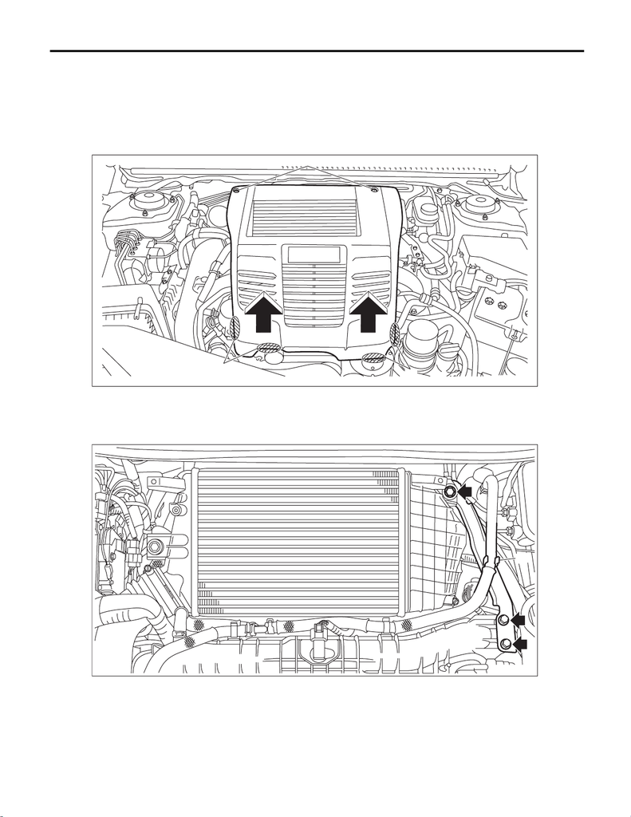

IN(w/o STI)-38

Intercooler

INTAKE (INDUCTION)

7. Intercooler

A: REMOVAL

1) Remove the collector cover.

(1) Remove the clips (A).

(2) Hold the shaded area (B) by hand and carefully pull the RH side (C) upward.

(3) Hold the shaded area (D) by hand and carefully pull the LH side (E) upward.

2) Disconnect the ground terminal from battery sensor. <Ref. to NT-5, BATTERY, NOTE, Note.>

3) Remove the brake booster vacuum hose from the clip (A).

4) Remove the bolts which secure the intercooler stay LH to the intercooler and intake manifold, and remove

the intercooler stay LH.

EX-03204

(A)

(B)

(C)

(E)

(D)

IN-03587

(A)

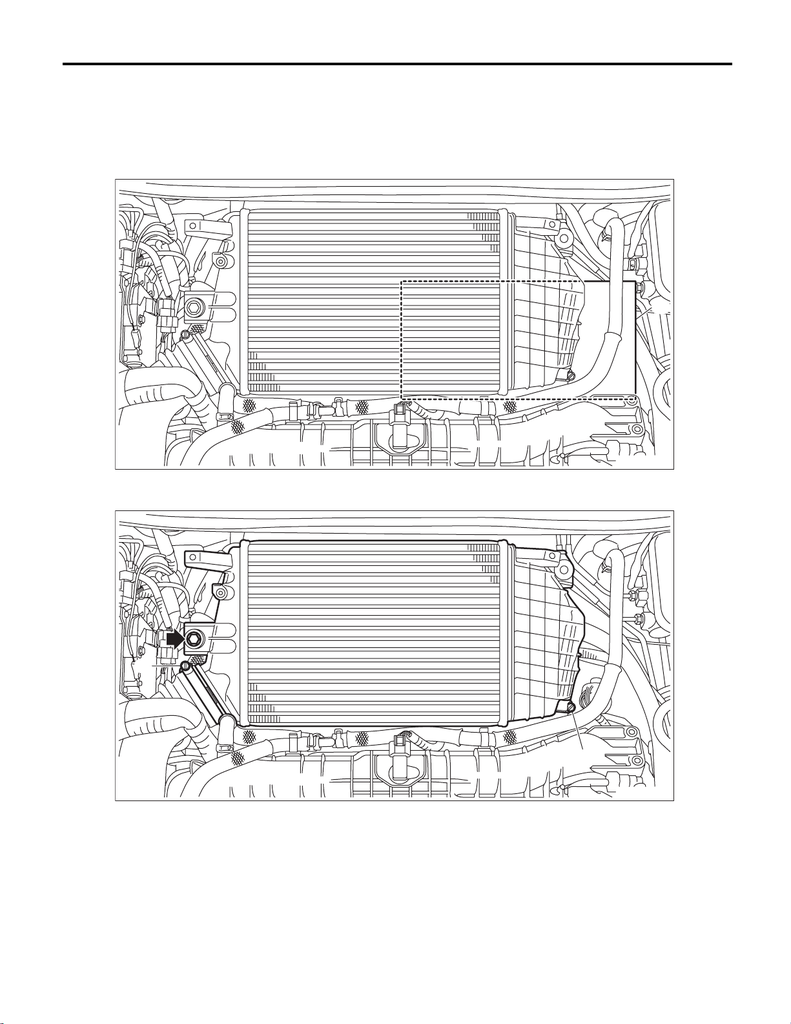

IN(w/o STI)-39

Intercooler

INTAKE (INDUCTION)

5) Insert the urethane sheet (A) between intercooler and operating cylinder. (MT model)

NOTE:

• This procedure is required to prevent the intercooler from touching the operating cylinder during intercooler

removal.

• Use the urethane sheet with the size (width × height × thickness) of approx. 300 mm × approx. 200 mm ×

approx. 10 mm (approx. 11.81 in × approx. 7.87 in × approx. 0.39 in).

6) Loosen the clamp (A) which holds the intake duct to intercooler.

7) Remove the bolts which secure the intercooler to the intercooler stay RH, and remove the intercooler.

IN-03588

(A)

IN-03540

(A)

(A)

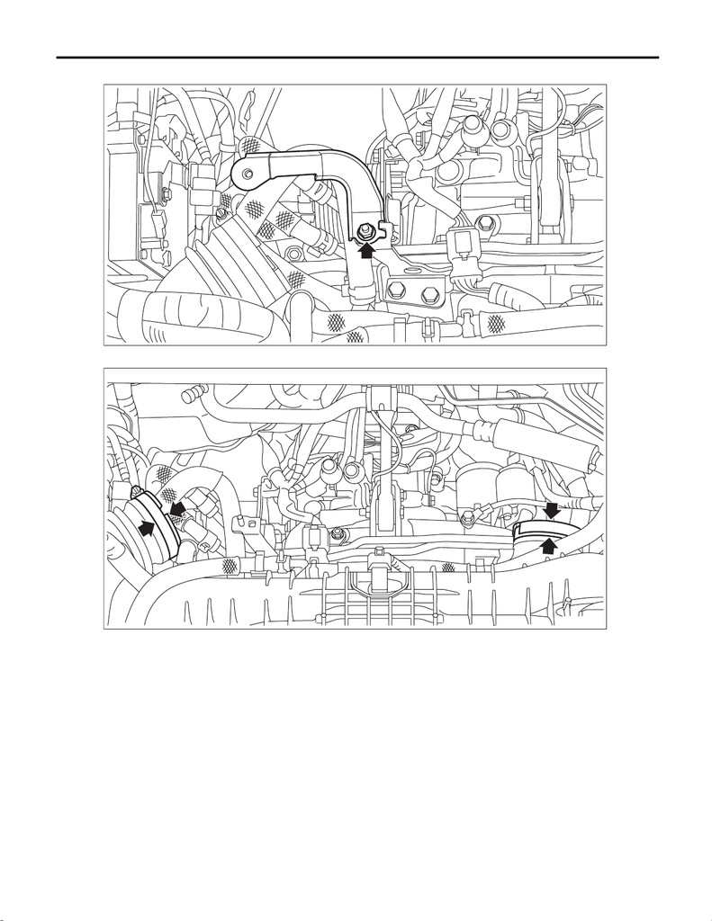

IN(w/o STI)-40

Intercooler

INTAKE (INDUCTION)

8) Remove the intercooler stay RH from the engine hanger stay.

9) Remove the insulator and clamp from intake duct.

IN-03541

IN-03542

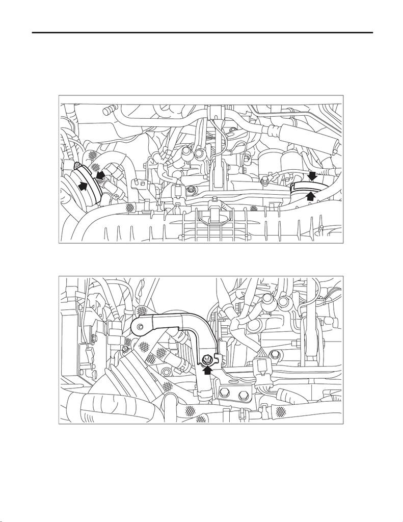

IN(w/o STI)-41

Intercooler

INTAKE (INDUCTION)

B: INSTALLATION

1) Install the insulator and clamp to the intake duct.

NOTE:

• Use a new insulator.

• Apply a thin coat of SUBARU PS fluid (K0515YA000) or liquid paraffin to the inner periphery of the insu-

lator.

2) Install the intercooler stay RH to the engine hanger stay.

Tightening torque:

16 N·m (1.6 kgf-m, 11.8 ft-lb)

IN-03542

IN-03541

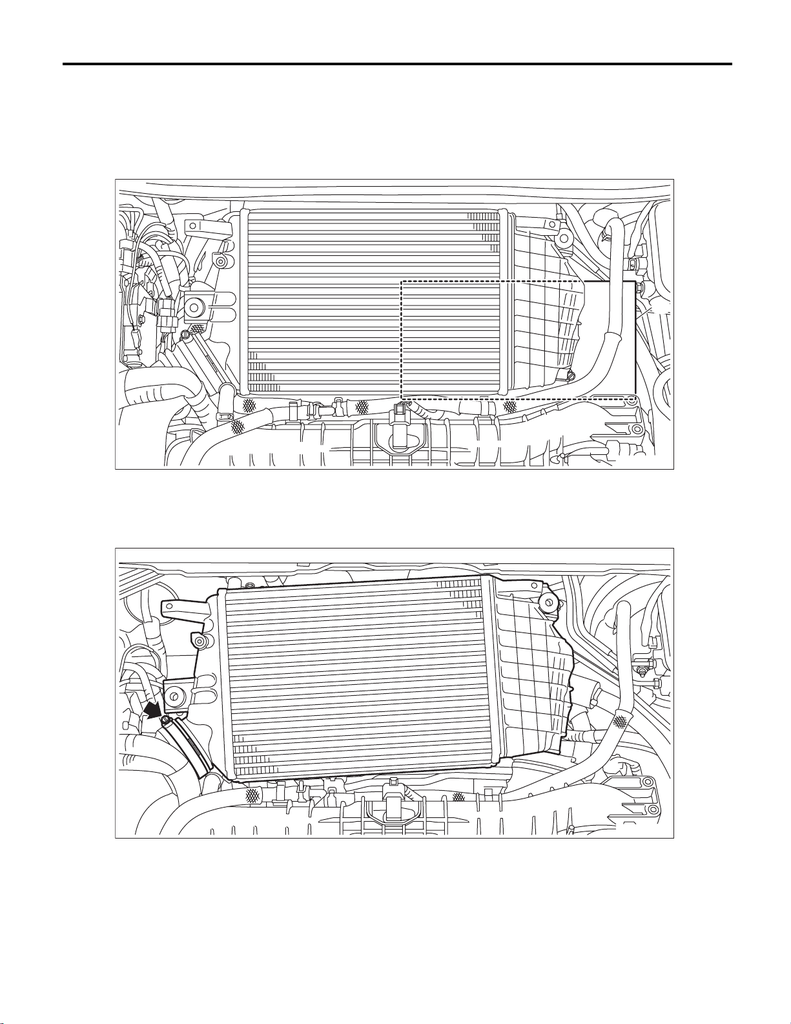

IN(w/o STI)-42

Intercooler

INTAKE (INDUCTION)

3) Set the urethane sheet (A) so that it covers the operating cylinder. (MT model)

NOTE:

• This procedure is required to prevent the intercooler from touching the operating cylinder during intercooler

installation.

• Use the urethane sheet with the size (width × height × thickness) of approx. 300 mm × approx. 200 mm ×

approx. 10 mm (approx. 11.81 in × approx. 7.87 in × approx. 0.39 in).

4) Insert the intercooler into the intake duct No. 2, and temporarily tighten the clamp which secures the intake

duct No. 2 to the intercooler.

NOTE:

When inserting the intercooler into the intake duct No. 2, be careful that the insulator is not turned over.

IN-03636

(A)

IN-03543

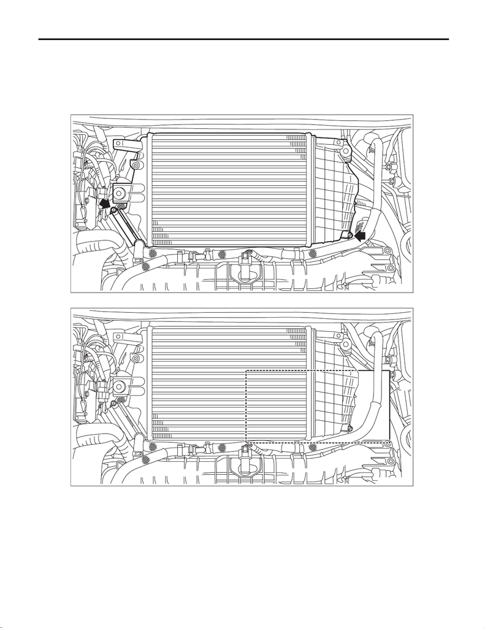

IN(w/o STI)-43

Intercooler

INTAKE (INDUCTION)

5) Insert the intercooler into the intake duct No. 3, and tighten the clamp which secures the intake duct to the

intercooler.

NOTE:

When inserting the intercooler into the intake duct No. 3, be careful that the insulator is not turned over.

Tightening torque:

3 N·m (0.3 kgf-m, 2.2 ft-lb)

6) Pull out the urethane sheet (A) between intercooler and operating cylinder. (MT model)

7) Set the intercooler stay LH to the intake manifold, and temporarily tighten the bolts which secure intercool-

er stay LH to the intake manifold.

8) Install the bolt which secures the intercooler to the intercooler stay.

IN-03544

IN-03636

(A)

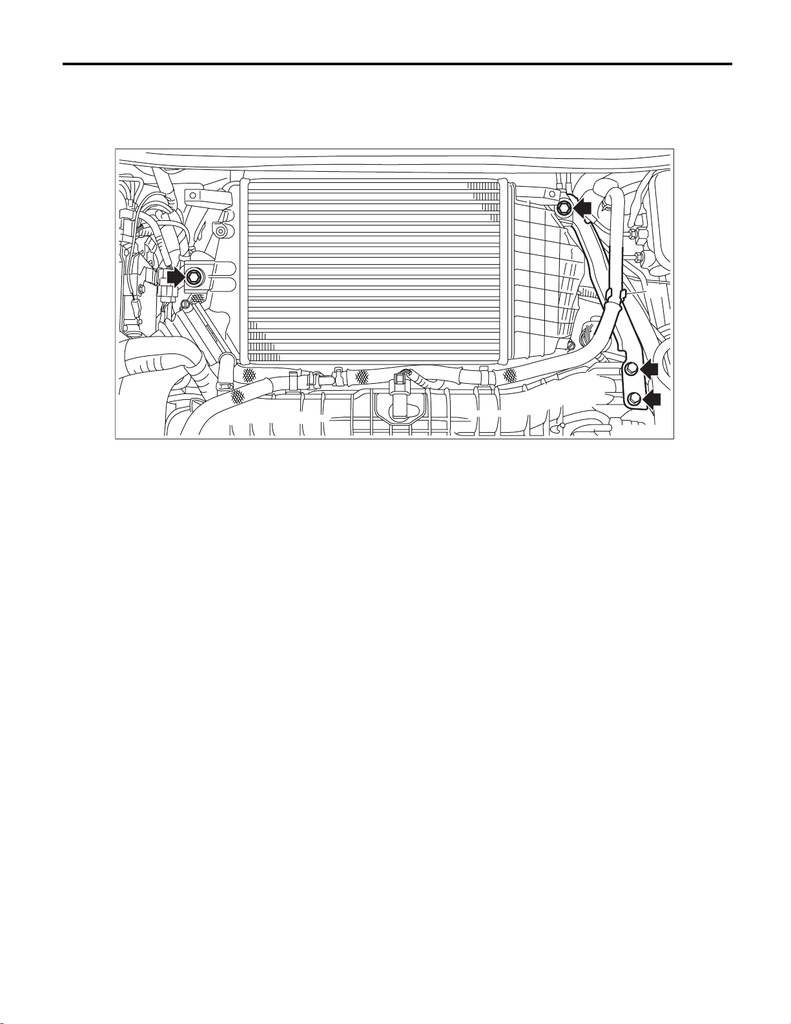

IN(w/o STI)-44

Intercooler

INTAKE (INDUCTION)

9) Tighten the bolts which secure the intercooler stay LH to the intake manifold, and install the brake booster

vacuum hose to the clip (A).

Tightening torque:

16 N·m (1.6 kgf-m, 11.8 ft-lb)

10) Connect the ground terminal to battery sensor. <Ref. to NT-5, BATTERY, NOTE, Note.>

11) Install the collector cover.

C: INSPECTION

Check that the intercooler and intercooler stay have no deformation, cracks or other damages.

IN-03545

(A)